# Statistical Inference - Course Project

### 02/01/2019

## Overview

This is the course project for the statistical inference class from Coursera The project consists of two parts:

1. A simulation exercise.
2. Basic inferential data analysis.

### Part 1: Simulation Exercise

In this project is investigated the exponential distribution in R and compare it with the Central Limit Theorem.The exponential distribution can be simulated in R with rexp(n, lambda) where lambda is the rate parameter. The mean of exponential distribution is 1/lambda and the standard deviation is also 1/lambda.

For the project, the following instructions were provided:

1. Set lambda = 0.2 for all of the simulations.
2. Investigate the distribution of averages of 40 exponentials.
3. Do a thousand simulations.

### Part 2: Basic Inferential Data Analysis Instructions

In the second portion of the project, we’re going to analyze the ToothGrowth data in the R datasets package.

1. The ToothGrowth data is loaded and some basic exploratory data analyses is performed.
2. A basic summary of the data is provided.
3. Confidence intervals and/or hypothesis tests are used to compare tooth growth by supp and dose.
4. Conclusions and the assumptions needed for conclusions are stated.

## Part 1: Simulation Excercise

First we create the 1000 simulations of the exponential distribution.

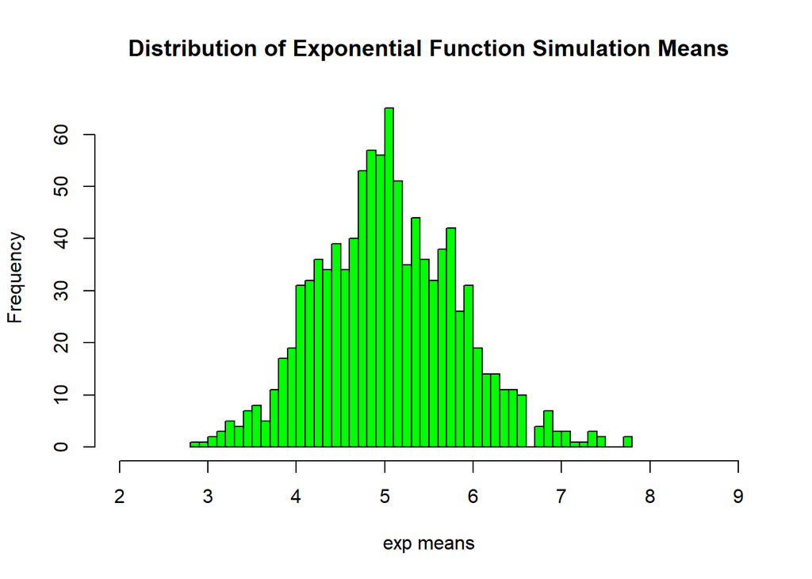

```r
set.seed(2019)
lambda <- 0.2
n<- 40
sim <- 1000
simSample <- replicate(sim,rexp(n, lambda))
means <- means <- apply(simSample, 2, mean)
hist(means, breaks = 40, main = "Distribution of Exponential Function Simulation Means", xlab = "exp means", xlim = c(2,9),col = "green")
```

#### Compare the theoretical mean with the mean of the distribution.

The theoritical mean is 1/lambda. We compare it with the mean of the distribution of the simulation means.

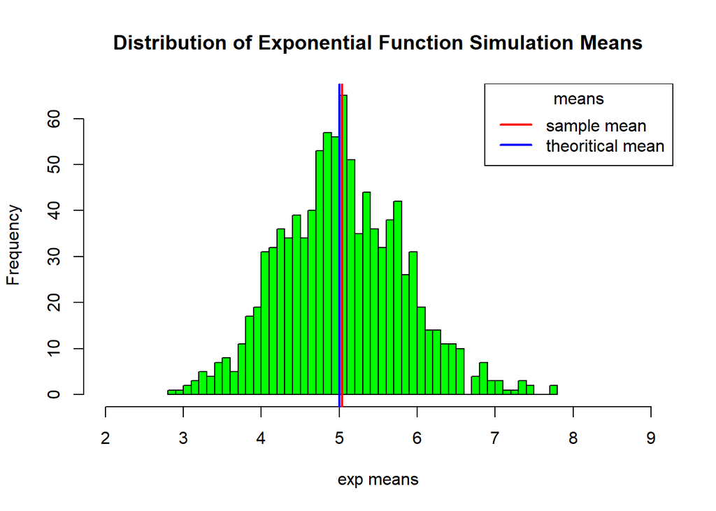

```r
theoritical_mean <- 1/lambda
ms<- round(mean(means),4)
hist(means, breaks = 40, main = "Distribution of Exponential Function Simulation Means", xlab = "exp means", xlim = c(2,9),col = "green")
abline(v = mean(means), col= "red", lwd = "2")
abline(v = theoritical_mean,col = "blue", lwd = "2")
legend("topright", c("sample mean", "theoritical mean"), col = c("red", "blue"), title = "means", lwd = 2)
```

The theoritical value of mean is m = 5 and the mean of the distribution is v = 5.0388.

#### Compare the theoritical variance and the variance of the sample.

We are going to vompare the varianc eof the sample with the theoritcal variance.

```r
theoritical_sd <- round((1/lambda)/sqrt(n),4)
sample_sd <- round(sd(means),4)
theoritical_var <- round(theoritical_sd^2,4)
sample_var <- round(sample_sd^2,4)
```

The theoritical variance is 0.625 and the variance of the sample is 0.6254. Respectively, the theoritical standard deviation is 0.7906 and the standard deviation of the distribution of the means of the sample is 0.7908.

#### Show that the distribution is approximately normal.

We are going to investigate whether the exponential distribution is approximately normal. According to the Central Limit Theorem, the means of the sample simulations should follow a normal distribution.

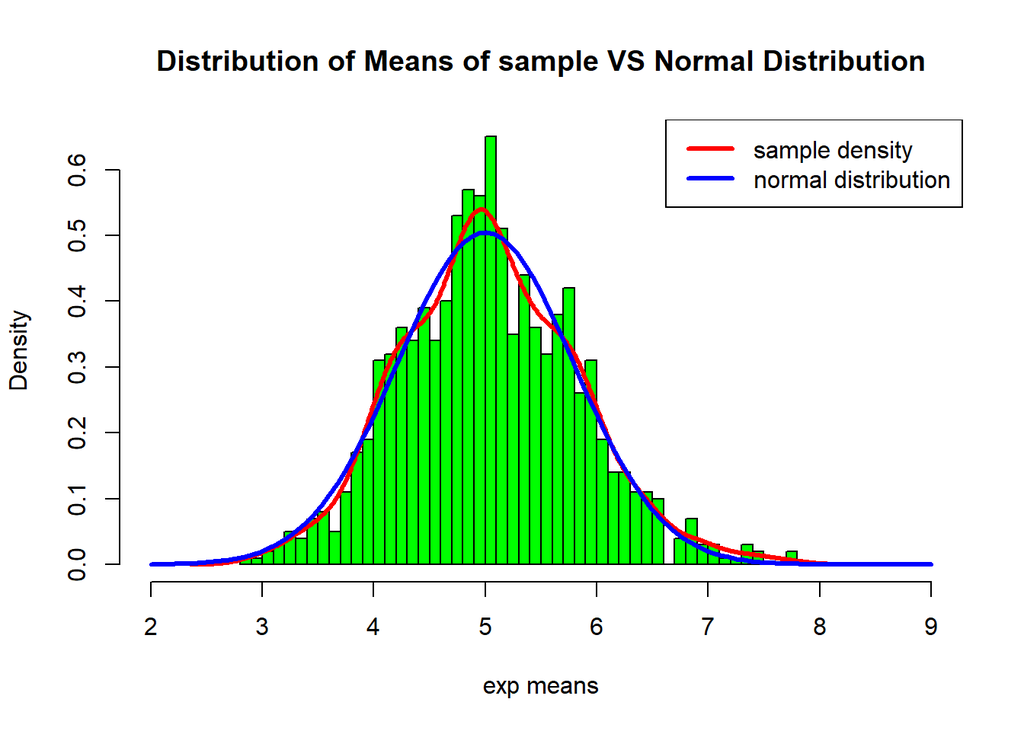

```r
hist(means, breaks = 40, main = "Distribution of Means of sample VS Normal Distribution", xlab = "exp means", xlim = c(2,9),col = "green", probability = TRUE)
lines(density(means), lwd=3, col="red")
curve(dnorm(x, mean=theoritical_mean, sd=sqrt(theoritical_var)),col = "blue", lwd = 3, add=TRUE, yaxt="n")
legend("topright", c("sample density", "normal distribution"), col = c("red", "blue"), lwd = 3)
```

In the above graphics, the red line represents the distribution of the means of the simulated samples, when the blue line represents the respective normal distribution. As it is easy to see from the graph, the distribution of the means of the sample approaches the normal distribution, according to the Central Limit Theory. If we increased our number of samples (currently 1000), the distribution would be even closer to the normal distribution.

## Part 2: Basic Inferential Data Analysis

In the second portion of the project, the ToothGrowth data in the R datasets package is analyzed.

1. Load the ToothGrowth data and perform basic exploratory data analyses
2. Provide a basic summary of the data.
3. Use confidence intervals and/or hypothesis tests to compare tooth growth by supp and dose. (Only use the techniques from class, even if there’s other approaches worth considering)
4. State conclusions and the assumptions needed for conclusions.

#### Load the ToothGrowth data and summarize the data.

Load libraries

```r
library(datasets)
library(ggplot2)
library(graphics)
library(dplyr)
```

Load and summarize the data.

```r
data("ToothGrowth")
str(ToothGrowth)
```

```
## 'data.frame':    60 obs. of  3 variables:
##  $ len : num  4.2 11.5 7.3 5.8 6.4 10 11.2 11.2 5.2 7 ...
##  $ supp: Factor w/ 2 levels "OJ","VC": 2 2 2 2 2 2 2 2 2 2 ...
##  $ dose: num  0.5 0.5 0.5 0.5 0.5 0.5 0.5 0.5 0.5 0.5 ...
```

```r
head(ToothGrowth)
```

```
##    len supp dose
## 1  4.2   VC  0.5
## 2 11.5   VC  0.5
## 3  7.3   VC  0.5
## 4  5.8   VC  0.5
## 5  6.4   VC  0.5
## 6 10.0   VC  0.5
```

```r
summary(ToothGrowth)
```

```
##       len        supp         dose
##  Min.   : 4.20   OJ:30   Min.   :0.500
##  1st Qu.:13.07   VC:30   1st Qu.:0.500
##  Median :19.25           Median :1.000
##  Mean   :18.81           Mean   :1.167
##  3rd Qu.:25.27           3rd Qu.:2.000
##  Max.   :33.90           Max.   :2.000
```

```r
levels(ToothGrowth$supp)
```

```
## [1] "OJ" "VC"
```

```r
levels(ToothGrowth$dose)
```

[output not shown]

```r
by(ToothGrowth$len, INDICES = list(ToothGrowth$supp, ToothGrowth$dose), summary)
```

```
## : OJ
## : 0.5
##    Min. 1st Qu.  Median    Mean 3rd Qu.    Max.
##    8.20    9.70   12.25   13.23   16.18   21.50
## --------------------------------------------------------
## : VC
## : 0.5
##    Min. 1st Qu.  Median    Mean 3rd Qu.    Max.
##    4.20    5.95    7.15    7.98   10.90   11.50
## --------------------------------------------------------
## : OJ
## : 1
##    Min. 1st Qu.  Median    Mean 3rd Qu.    Max.
##   14.50   20.30   23.45   22.70   25.65   27.30
## --------------------------------------------------------
## : VC
## : 1
##    Min. 1st Qu.  Median    Mean 3rd Qu.    Max.
##   13.60   15.28   16.50   16.77   17.30   22.50
## --------------------------------------------------------
## : OJ
## : 2
##    Min. 1st Qu.  Median    Mean 3rd Qu.    Max.
##   22.40   24.57   25.95   26.06   27.07   30.90
## --------------------------------------------------------
## : VC
## : 2
##    Min. 1st Qu.  Median    Mean 3rd Qu.    Max.
##   18.50   23.38   25.95   26.14   28.80   33.90
```

#### Exploratory graphs

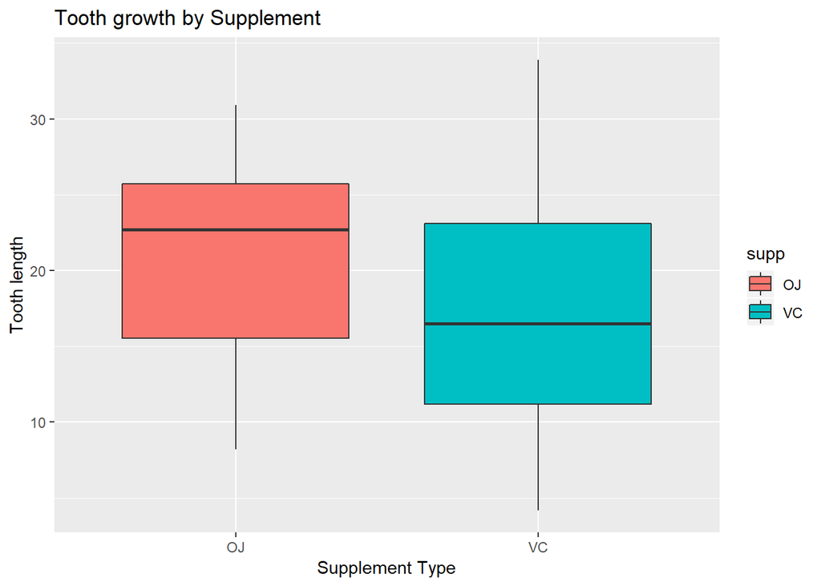

```r
g <- ggplot(aes(x = supp, y = len), data = ToothGrowth) + geom_boxplot(aes(fill = supp))+xlab("Supplement Type")+ylab("Tooth length")+ ggtitle("Tooth growth by Supplement")
plot(g)
```

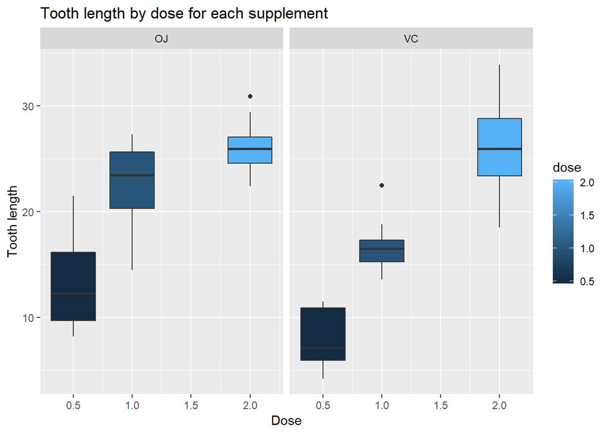

```r
gg <- ggplot(aes(x = dose, y = len), data = ToothGrowth) + geom_boxplot(aes(fill = dose, group = dose))+xlab("Dose")+ylab("Tooth length")+facet_grid(~supp) + ggtitle("Tooth length by dose for each supplement")
plot(gg)
```

#### Compare tooth growth with supplement

We make the null hypothesis H0 that the difference in means of the tooth length raise for each of the two supplements is equal to 0 and we use t-test.

```r
t.test(len~supp, data = ToothGrowth)
```

```
##
##  Welch Two Sample t-test
##
## data:  len by supp
## t = 1.9153, df = 55.309, p-value = 0.06063
## alternative hypothesis: true difference in means is not equal to 0
## 95 percent confidence interval:
##  -0.1710156  7.5710156
## sample estimates:
## mean in group OJ mean in group VC
##         20.66333         16.96333
```

The p-value is 0.06, which is greater than 0.05 and as a result we cannot reject the null hypothesis that the supplements have no effect on tooth growth, for the 95% confidence interval. Also, zero is contained in the 95% confidence interval. Because, 0.06 is close to 0.05, it is possible that with more data we would be able to reject the null hypthesis.

#### Compare tooth growth with dose

We compare the tooth length raise for two different values of the dose each time with a different t-test

We make the null hypothesis H0 that the difference in means of the tooth length raise for each of the two doses (o.5 and 1.0) is equal to 0 and we use t-test.

```r
dsub <- ToothGrowth[ToothGrowth$dose %in% c(0.5,1),]
t.test(len~dose, data = dsub)
```

```
##
##  Welch Two Sample t-test
##
## data:  len by dose
## t = -6.4766, df = 37.986, p-value = 1.268e-07
## alternative hypothesis: true difference in means is not equal to 0
## 95 percent confidence interval:
##  -11.983781  -6.276219
## sample estimates:
## mean in group 0.5   mean in group 1
##            10.605            19.735
```

We make the null hypothesis H0 that the difference in means of the tooth length raise for each of the two doses (o.5 and 2.0) is equal to 0 and we use t-test.

```r
dsub <- ToothGrowth[ToothGrowth$dose %in% c(0.5,2),]
t.test(len~dose, data = dsub)
```

```
##
##  Welch Two Sample t-test
##
## data:  len by dose
## t = -11.799, df = 36.883, p-value = 4.398e-14
## alternative hypothesis: true difference in means is not equal to 0
## 95 percent confidence interval:
##  -18.15617 -12.83383
## sample estimates:
## mean in group 0.5   mean in group 2
##            10.605            26.100
```

We make the null hypothesis H0 that the difference in means of the tooth length raise for each of the two doses (1.0 and 2.0) is equal to 0 and we use t-test.

```r
dsub <- ToothGrowth[ToothGrowth$dose %in% c(1,2),]
t.test(len~dose, data = dsub)
```

```
##
##  Welch Two Sample t-test
##
## data:  len by dose
## t = -4.9005, df = 37.101, p-value = 1.906e-05
## alternative hypothesis: true difference in means is not equal to 0
## 95 percent confidence interval:
##  -8.996481 -3.733519
## sample estimates:
## mean in group 1 mean in group 2
##          19.735          26.100
```

In all three cases of tooth length comparison in relation with dose, we can see that the p-value is much smaller than 0.05, which means we can safely reject the null hypothesis that there is no effect of dose in tooth length. Also, in all of three cases the 95% confidence intervals don’t contain zero.

#### Conclusions

Assumptions  
1. For the t-tests, the variances are assumed to be different for the two groups being compared. This assumption is less stronger than the case in which the variances are assumed to be equal.  
2. The sample is representative of the population